# IODS course project

Anna Syreeni

# The course about Open data and Open data science.

-We’ll use open data -We will analyze data with open source software tools -We will understand the basics of important analysis methods

## My GitHub reposity can be found here

https://github.com/atiitu/IODS-project

## Tools

R, RStudio, GitHub

# Week2 excersize: Regression models

Read and study data

The data is in .txt -format and is tab-separated.

```r
setwd("~/Tyojuttuja/opinnot/GitHub/IODS-project")
data <- read.table(file = "~/Tyojuttuja/opinnot/GitHub/IODS-project/data/learning2014.txt", sep="\t")
#I changed the working directory back to project
```

The data table was studied with relevant r-functions such as str(), head() and dim().

The data is about learning attitudes and points got from an exam. In this dataset, there are 166 rows and 7 columns: gender, age, attitude, deep, stra, surf, points. Attitude is the learning attitude (1-5) and deep, stra and surf are means of different kind of learning-related questions (deep, surface or strategic, scales 1-5). Points-column is the points got from the exam.

Please find more detail about the data in here http://www.helsinki.fi/~kvehkala/JYTmooc/JYTOPKYS3-meta.txt

Summaries of all variables was studied with summary function: Gender:

```r
summary(data$gender)
```

```
##   F   M
## 110  56
```

Age:

```r
summary(data$age)
```

```
##    Min. 1st Qu.  Median    Mean 3rd Qu.    Max.
##   17.00   21.00   22.00   25.51   27.00   55.00
```

Attitude:

```r
summary(data$attitude)
```

```
##    Min. 1st Qu.  Median    Mean 3rd Qu.    Max.
##   1.400   2.600   3.200   3.143   3.700   5.000
```

Deep questions:

```r
summary(data$deep)
```

```
##    Min. 1st Qu.  Median    Mean 3rd Qu.    Max.
##   1.583   3.333   3.667   3.680   4.083   4.917
```

Strategic questions:

```r
summary(data$stra)
```

```
##    Min. 1st Qu.  Median    Mean 3rd Qu.    Max.
##   1.250   2.625   3.188   3.121   3.625   5.000
```

Surface questions:

```r
summary(data$surf)
```

```
##    Min. 1st Qu.  Median    Mean 3rd Qu.    Max.
##   1.583   2.417   2.833   2.787   3.167   4.333
```

Exam points:

```r
summary(data$points)
```

```
##    Min. 1st Qu.  Median    Mean 3rd Qu.    Max.
##    7.00   19.00   23.00   22.72   27.75   33.00
```

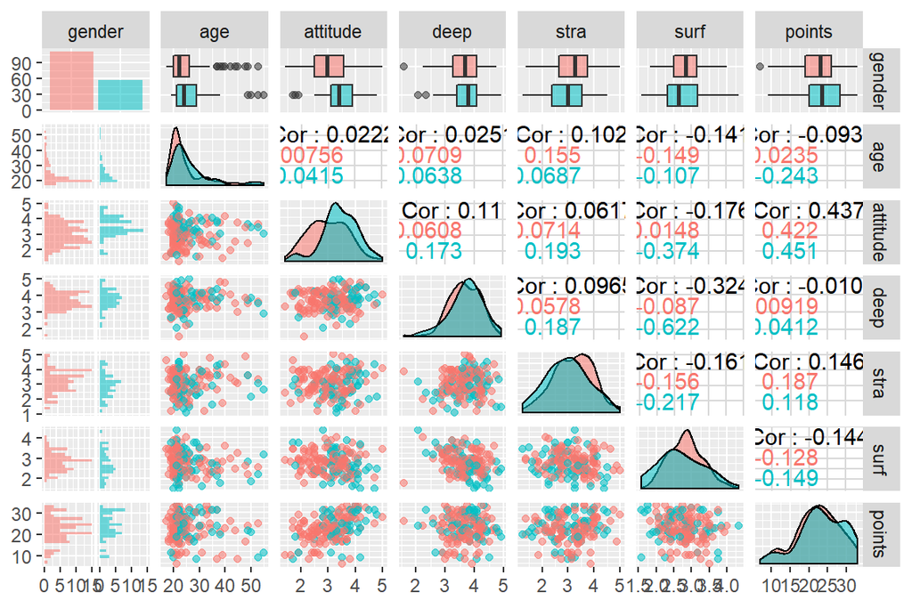

```r
#Access the GGally and ggplot2 libraries
library(GGally)
library(ggplot2)

# Variable dispersions and correlations can be studied with ggpairs-function

data_correlations <- ggpairs(data, mapping =  aes(col= gender, alpha = 0.3), lower = list(combo = wrap("facethist", bins = 20)))

data_correlations
```

From the data distributions, we can notice that some variables are about normally distributed (deep, stra and surf questions mainly). On the other hand age is right-tailed: most students are in their twenties but then there are a couple of 30-50 year old students. It looks like the exam points correlates mostly with attitude (r=0.43).This correlation is similar in males and females. The attitude does not correlate strongly with age (r<0.1)

```r
model <- lm(points ~ attitude + stra + surf, data = data)
summary(model)
```

```
##
## Call:
## lm(formula = points ~ attitude + stra + surf, data = data)
##
## Residuals:
##      Min       1Q   Median       3Q      Max
## -17.1550  -3.4346   0.5156   3.6401  10.8952
##
## Coefficients:
##             Estimate Std. Error t value Pr(>|t|)
## (Intercept)  11.0171     3.6837   2.991  0.00322 **
## attitude      3.3952     0.5741   5.913 1.93e-08 ***
## stra          0.8531     0.5416   1.575  0.11716
## surf         -0.5861     0.8014  -0.731  0.46563
## ---
## Signif. codes:  0 '***' 0.001 '**' 0.01 '*' 0.05 '.' 0.1 ' ' 1
##
## Residual standard error: 5.296 on 162 degrees of freedom
## Multiple R-squared:  0.2074, Adjusted R-squared:  0.1927
## F-statistic: 14.13 on 3 and 162 DF,  p-value: 3.156e-08
```

Exam points correlated stronly with attitude (Beta=3.4 SE 0.6, P = 2*10-8) in a linear regression model with strategic (stra) and surface (surf) questions. This means that one unit increase in (mean) attitude (scale 1-5) will in increase your exam success by 3.4. The question variables did not significantly affect the exam points (P-values > 0.1).

```r
model2 <- lm(points ~ attitude, data = data)
summary(model2)
```

```
##
## Call:
## lm(formula = points ~ attitude, data = data)
##
## Residuals:
##      Min       1Q   Median       3Q      Max
## -16.9763  -3.2119   0.4339   4.1534  10.6645
##
## Coefficients:
##             Estimate Std. Error t value Pr(>|t|)
## (Intercept)  11.6372     1.8303   6.358 1.95e-09 ***
## attitude      3.5255     0.5674   6.214 4.12e-09 ***
## ---
## Signif. codes:  0 '***' 0.001 '**' 0.01 '*' 0.05 '.' 0.1 ' ' 1
##
## Residual standard error: 5.32 on 164 degrees of freedom
## Multiple R-squared:  0.1906, Adjusted R-squared:  0.1856
## F-statistic: 38.61 on 1 and 164 DF,  p-value: 4.119e-09
```

When the learning-variables were removed from the statistical model, the effect of attitude on exam points remained quite unchanged (Beta=3.5, SE 0.6, P = 4.2*10-9) meaning that one unit increase in (mean) attitude (scale 1-5) will in increase your exam success by 3.5. Attitude explaines 18.6% of the variability in the exam points (adjusted R-squared)

Assumptions of the regression model was tested with diagnostic plots.

Residuals vs. fitted values picture showed that the residuals do not have non-linear patters and they are nicely and evenly scattered around the horizontal line.

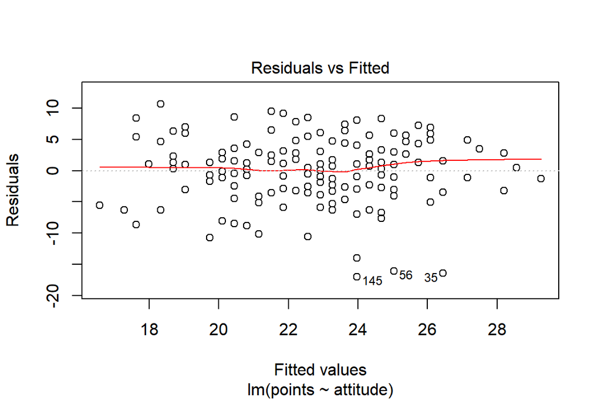

```r
#Residuals vs Fitted values
plot(model2, which = c(1))
```

The normal QQ-plot showed that residuals are quite normally distributed. This is also an assumption in of the linear regression model. The residuals should roughly follow the straight line in the QQ-plot.

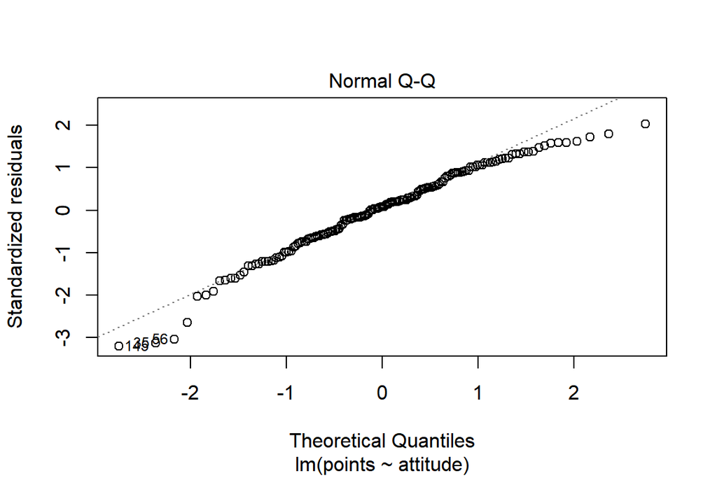

```r
#Normal QQ-plot
plot(model2, which = c(2))
```

There were no significant outlier in the data that would greatly affect the results, as shown in the residuals vs. leverage diagnostic plot.

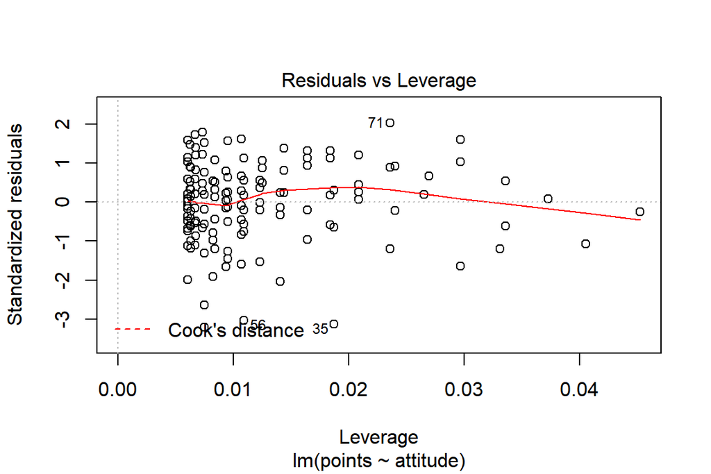

```r
#Residuals vs Leverage.
plot(model2, which = c(5))
```

# Week3: Logistic regression"

In this week’s excersize we’ll analyze data on student’s alcohol consumption. It is combined from two questionnaires originally downloaded from: https://archive.ics.uci.edu/ml/datasets/Student+Performance#

Data contains 382 observations (students) of a total of 35 variables, which are listed below:

```
##  [1] "school"     "sex"        "age"        "address"    "famsize"
##  [6] "Pstatus"    "Medu"       "Fedu"       "Mjob"       "Fjob"
## [11] "reason"     "nursery"    "internet"   "guardian"   "traveltime"
## [16] "studytime"  "failures"   "schoolsup"  "famsup"     "paid"
## [21] "activities" "higher"     "romantic"   "famrel"     "freetime"
## [26] "goout"      "Dalc"       "Walc"       "health"     "absences"
## [31] "G1"         "G2"         "G3"         "alc_use"    "high_use"
```

The variables are:

1 school - student’s school (binary: “GP” - Gabriel Pereira or “MS” - Mousinho da Silveira)  
2 sex - student’s sex (binary: “F” - female or “M” - male)  
3 age - student’s age (numeric: from 15 to 22)  
4 address - student’s home address type (binary: “U” - urban or “R” - rural)  
5 famsize - family size (binary: “LE3” - less or equal to 3 or “GT3” - greater than 3)  
6 Pstatus - parent’s cohabitation status (binary: “T” - living together or “A” - apart)  
7 Medu - mother’s education (numeric: 0 - none, 1 - primary education (4th grade), 2 - 5th to 9th grade, 3 - secondary education or 4 - higher education)  
8 Fedu - father’s education (numeric: 0 - none, 1 - primary education (4th grade), 2 - 5th to 9th grade, 3 - secondary education or 4 - higher education)  
9 Mjob - mother’s job (nominal: “teacher”, “health” care related, civil “services” (e.g. administrative or police), “at_home” or “other”)  
10 Fjob - father’s job (nominal: “teacher”, “health” care related, civil “services” (e.g. administrative or police), “at_home” or “other”)  
11 reason - reason to choose this school (nominal: close to “home”, school “reputation”, “course” preference or “other”)  
12 guardian - student’s guardian (nominal: “mother”, “father” or “other”)  
13 traveltime - home to school travel time (numeric: 1 - <15 min., 2 - 15 to 30 min., 3 - 30 min. to 1 hour, or 4 - >1 hour)  
14 studytime - weekly study time (numeric: 1 - <2 hours, 2 - 2 to 5 hours, 3 - 5 to 10 hours, or 4 - >10 hours)  
15 failures - number of past class failures (numeric: n if 1<=n<3, else 4)  
16 schoolsup - extra educational support (binary: yes or no)  
17 famsup - family educational support (binary: yes or no)  
18 paid - extra paid classes within the course subject (Math or Portuguese) (binary: yes or no)  
19 activities - extra-curricular activities (binary: yes or no)  
20 nursery - attended nursery school (binary: yes or no)  
21 higher - wants to take higher education (binary: yes or no)  
22 internet - Internet access at home (binary: yes or no)  
23 romantic - with a romantic relationship (binary: yes or no)  
24 famrel - quality of family relationships (numeric: from 1 - very bad to 5 - excellent)  
25 freetime - free time after school (numeric: from 1 - very low to 5 - very high)  
26 goout - going out with friends (numeric: from 1 - very low to 5 - very high)  
27 Dalc - workday alcohol consumption (numeric: from 1 - very low to 5 - very high)  
28 Walc - weekend alcohol consumption (numeric: from 1 - very low to 5 - very high)  
29 health - current health status (numeric: from 1 - very bad to 5 - very good)  
30 absences - number of school absences (numeric: from 0 to 93)

these grades are related with the course subject, Math or Portuguese:  
31 G1 - first period grade (numeric: from 0 to 20)  
32 G2 - second period grade (numeric: from 0 to 20)  
33 G3 - final grade (numeric: from 0 to 20, output target)  
34 alc_use - average alcohol use on weekdays and weekends (variable created from averagin Dalc and Walc)  
35 high_use - TRUE or FALSE if the use of alchol is >2 (variable created in create_alc.R)  
******************************************************************

## Explore associations with high use of alcohol

With this data, I will analyze how going out with friends (goout), mother’s education (Medu), father’s education (Fedu) and first grade (G1) associate with the use of alcohol (low or high). I hypothesize that:  
-those that go more out with friends think more alcohol  
-low mother and father education associate with higher alcohol use  
-low first grades associate with high alcohol use

Going out:

As hypothesized, 60% of those that are going out with frends the most (5 on 1-5 scale) are high users of alcohol (>2 on 1-5 scale). Of those that go out the least (1), only 13,6% are high alcohol users.

```r
library(dplyr)
```

```r
library(ggplot2)
mytable <- table(high_use = alc$high_use, going_out = alc$goout)
mytable
```

```
##         going_out
## high_use   1   2   3   4   5
##    FALSE  19  84 103  41  21
##    TRUE    3  16  23  40  32
```

```r
prop.table(mytable, 2)
```

```
##         going_out
## high_use         1         2         3         4         5
##    FALSE 0.8636364 0.8400000 0.8174603 0.5061728 0.3962264
##    TRUE  0.1363636 0.1600000 0.1825397 0.4938272 0.6037736
```

Mother’s and father’s education:

```r
mytable <- table(high_use = alc$high_use, mothers_education = alc$Medu)
mytable
```

```
##         mothers_education
## high_use  0  1  2  3  4
##    FALSE  1 33 80 59 95
##    TRUE   2 18 18 36 40
```

```r
prop.table(mytable, 2)
```

```
##         mothers_education
## high_use         0         1         2         3         4
##    FALSE 0.3333333 0.6470588 0.8163265 0.6210526 0.7037037
##    TRUE  0.6666667 0.3529412 0.1836735 0.3789474 0.2962963
```

Father’s education does not seem to associate with student’s alcohol use as seen from the table below. There were only two students whose father had the lowest education. It seems that in this dataset, parental education do not affect student’s alcohol usage.

```r
mytable <- table(high_use = alc$high_use, fathers_education = alc$Fedu)
mytable
```

```
##         fathers_education
## high_use  0  1  2  3  4
##    FALSE  2 53 75 72 66
##    TRUE   0 24 30 27 33
```

```r
prop.table(mytable, 2)
```

```
##         fathers_education
## high_use         0         1         2         3         4
##    FALSE 1.0000000 0.6883117 0.7142857 0.7272727 0.6666667
##    TRUE  0.0000000 0.3116883 0.2857143 0.2727273 0.3333333
```

First grades:

As seen from the box-plot, lower grades seem to associate with higher alcohol useage. (G1-variable). This notion goes in the hypothetised direction.

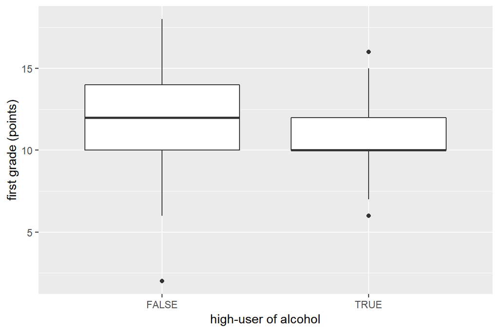

```r
# initialize a plot of high_use and G3
g1 <- ggplot(alc, aes(x = high_use, y = G1))

# define the plot as a boxplot and draw it
g1 + geom_boxplot() + ylab("first grade (points)") + xlab("high-user of alcohol")
```

## Statistical testing of associations with high use of alcohol

The association with variables and high alcohol is next tested with logistic regression. In the first model, going out with friends (scale 1-5 ) and was tested as a explanatory variable. As hypothetized, going out with friends is associated with high alcohol consumption (p = 5.210^-11) with OR (97.5%CI) of 2.14(1.71,2.70).

```r
#logistic regression model
model <- glm(high_use ~ goout, data = alc, family = "binomial")

# print out a summary of the model
summary(model)
```

```
##
## Call:
## glm(formula = high_use ~ goout, family = "binomial", data = alc)
##
## Deviance Residuals:
##     Min       1Q   Median       3Q      Max
## -1.3721  -0.7672  -0.5450   0.9945   2.3082
##
## Coefficients:
##             Estimate Std. Error z value Pr(>|z|)
## (Intercept)  -3.3512     0.4151  -8.073 6.84e-16 ***
## goout         0.7596     0.1157   6.564 5.23e-11 ***
## ---
## Signif. codes:  0 '***' 0.001 '**' 0.01 '*' 0.05 '.' 0.1 ' ' 1
##
## (Dispersion parameter for binomial family taken to be 1)
##
##     Null deviance: 465.68  on 381  degrees of freedom
## Residual deviance: 415.68  on 380  degrees of freedom
## AIC: 419.68
##
## Number of Fisher Scoring iterations: 4
```

```r
# print out the coefficients of the model
coef <-coef(model)
# compute odds ratios (OR)
OR <- coef %>% exp

# compute confidence intervals (CI)
CI <- confint(model) %>% exp
# print out the odds ratios with their confidence intervals
cbind(OR, CI)
```

```
##                     OR      2.5 %     97.5 %
## (Intercept) 0.03504298 0.01505792 0.07687797
## goout       2.13743726 1.71351154 2.69965289
```

Parental education did not associate statistically significantly (P>0.05) with high use of alcohol,and odds ratios were close to one: mothernal education: OR (97.5%CI); 0.98 (0.75, 1.29) and father education: 1.06 (0.81, 1.38). This data therefore does not support my hypothesis that lower parental education would associate with higher alcohol intake of children (student).

```r
# Both variables are shown as integers (1-5) in the data. I think, these variables could have also been presented as factors, because education has true levels. No changes were made however, parental education was stuedied with numeric (integers 1-5 ) values.
```

```r
#logistic regression model
model <- glm(high_use ~ Medu + Fedu, data = alc, family = "binomial")

# print out a summary of the model
summary(model)
```

```
##
## Call:
## glm(formula = high_use ~ Medu + Fedu, family = "binomial", data = alc)
##
## Deviance Residuals:
##     Min       1Q   Median       3Q      Max
## -0.8758  -0.8495  -0.8292   1.5266   1.6043
##
## Coefficients:
##             Estimate Std. Error z value Pr(>|z|)
## (Intercept) -0.95912    0.32702  -2.933  0.00336 **
## Medu        -0.01553    0.13599  -0.114  0.90910
## Fedu         0.05743    0.13478   0.426  0.67005
## ---
## Signif. codes:  0 '***' 0.001 '**' 0.01 '*' 0.05 '.' 0.1 ' ' 1
##
## (Dispersion parameter for binomial family taken to be 1)
##
##     Null deviance: 465.68  on 381  degrees of freedom
## Residual deviance: 465.45  on 379  degrees of freedom
## AIC: 471.45
##
## Number of Fisher Scoring iterations: 4
```

```r
# print out the coefficients of the model
coef <-coef(model)

# compute odds ratios (OR)
OR <- coef %>% exp

# compute confidence intervals (CI)
CI <- confint(model) %>% exp
#print out the odds ratios with their confidence intervals
cbind(OR, CI)
```

```
##                    OR     2.5 %    97.5 %
## (Intercept) 0.3832287 0.1992008 0.7200188
## Medu        0.9845937 0.7538507 1.2865179
## Fedu        1.0591089 0.8139895 1.3824989
```

Last I hypotethized that lower first grades are associated with high alcohol use. This was true (p = 0.004, OR(97.5%CI):0.88(0.81,0.96)).

```r
#logistic regression model
model <- glm(high_use ~ G1, data = alc, family = "binomial")

# print out a summary of the model
summary(model)
```

```
##
## Call:
## glm(formula = high_use ~ G1, family = "binomial", data = alc)
##
## Deviance Residuals:
##     Min       1Q   Median       3Q      Max
## -1.3134  -0.9015  -0.7279   1.4108   1.8198
##
## Coefficients:
##             Estimate Std. Error z value Pr(>|z|)
## (Intercept)  0.56528    0.49487   1.142  0.25334
## G1          -0.12558    0.04328  -2.902  0.00371 **
## ---
## Signif. codes:  0 '***' 0.001 '**' 0.01 '*' 0.05 '.' 0.1 ' ' 1
##
## (Dispersion parameter for binomial family taken to be 1)
##
##     Null deviance: 465.68  on 381  degrees of freedom
## Residual deviance: 456.91  on 380  degrees of freedom
## AIC: 460.91
##
## Number of Fisher Scoring iterations: 4
```

```r
# print out the coefficients of the model
coef <-coef(model)

# compute odds ratios (OR)
OR <- coef %>% exp

# compute confidence intervals (CI)
CI <- confint(model) %>% exp
#print out the odds ratios with their confidence intervals
cbind(OR, CI)
```

```
##                    OR     2.5 %    97.5 %
## (Intercept) 1.7599464 0.6700469 4.6866051
## G1          0.8819812 0.8088857 0.9588772
```

# Week4: Clustering and classification

## Exploring Boston-data

For this week’s excersize we’ll use a Boston-dataset included in the MASS Package in R. Basically, the data is about per capita crime rate by town and some variables describing the towns. There are 14 variables on 506 towns included.

The variables in the Boston data are:  
crim = per capita crime rate by town  
zn = proportion of residential land zoned for lots over 25,000 sq.ft  
indus = proportion of non-retail business acres per town  
chas = Charles River dummy variable (= 1 if tract bounds river; 0 otherwise)  
nox = nitrogen oxides concentration (parts per 10 million)  
rm = average number of rooms per dwelling  
age = proportion of owner-occupied units built prior to 1940  
dis = weighted mean of distances to five Boston employment centres  
rad = index of accessibility to radial highways  
tax = full-value property-tax rate per $10,000  
ptratio = pupil-teacher ratio by town  
black = 1000(Bk - 0.63)^2 where Bk is the proportion of blacks by town  
lstat = lower status of the population (percent)  
medv = median value of owner-occupied homes in $1000s

The summaries of all variables are listed below. As seen from the summary, for example crime rate differs largely between towns: it ranges from 0.006 crimes from 89.0 crimes per capita.

```
##       crim                zn             indus            chas
##  Min.   : 0.00632   Min.   :  0.00   Min.   : 0.46   Min.   :0.00000
##  1st Qu.: 0.08204   1st Qu.:  0.00   1st Qu.: 5.19   1st Qu.:0.00000
##  Median : 0.25651   Median :  0.00   Median : 9.69   Median :0.00000
##  Mean   : 3.61352   Mean   : 11.36   Mean   :11.14   Mean   :0.06917
##  3rd Qu.: 3.67708   3rd Qu.: 12.50   3rd Qu.:18.10   3rd Qu.:0.00000
##  Max.   :88.97620   Max.   :100.00   Max.   :27.74   Max.   :1.00000
##       nox               rm             age              dis
##  Min.   :0.3850   Min.   :3.561   Min.   :  2.90   Min.   : 1.130
##  1st Qu.:0.4490   1st Qu.:5.886   1st Qu.: 45.02   1st Qu.: 2.100
##  Median :0.5380   Median :6.208   Median : 77.50   Median : 3.207
##  Mean   :0.5547   Mean   :6.285   Mean   : 68.57   Mean   : 3.795
##  3rd Qu.:0.6240   3rd Qu.:6.623   3rd Qu.: 94.08   3rd Qu.: 5.188
##  Max.   :0.8710   Max.   :8.780   Max.   :100.00   Max.   :12.127
##       rad              tax           ptratio          black
##  Min.   : 1.000   Min.   :187.0   Min.   :12.60   Min.   :  0.32
##  1st Qu.: 4.000   1st Qu.:279.0   1st Qu.:17.40   1st Qu.:375.38
##  Median : 5.000   Median :330.0   Median :19.05   Median :391.44
##  Mean   : 9.549   Mean   :408.2   Mean   :18.46   Mean   :356.67
##  3rd Qu.:24.000   3rd Qu.:666.0   3rd Qu.:20.20   3rd Qu.:396.23
##  Max.   :24.000   Max.   :711.0   Max.   :22.00   Max.   :396.90
##      lstat            medv
##  Min.   : 1.73   Min.   : 5.00
##  1st Qu.: 6.95   1st Qu.:17.02
##  Median :11.36   Median :21.20
##  Mean   :12.65   Mean   :22.53
##  3rd Qu.:16.95   3rd Qu.:25.00
##  Max.   :37.97   Max.   :50.00
```

As seen from the correlation matrix, for example accessibility to radial highways (rad, calculated correlation r=0.63) and full-value propery-tax rate (tax, calculated r = 0.58) correlate positively with per capita crime rate. Living far Boston five Boston employment centres associates with lower air nitric oxide concentration (correlation of dis and nos, r = -0.77)

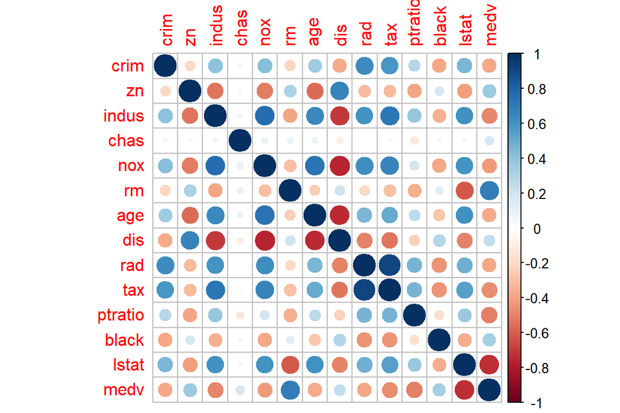

Next I standarsized all variables in the Boston data. Summaries of the variables are printed below. You can easily see that all standarized variables now have a mean of 0.

```
##       crim                 zn               indus
##  Min.   :-0.419367   Min.   :-0.48724   Min.   :-1.5563
##  1st Qu.:-0.410563   1st Qu.:-0.48724   1st Qu.:-0.8668
##  Median :-0.390280   Median :-0.48724   Median :-0.2109
##  Mean   : 0.000000   Mean   : 0.00000   Mean   : 0.0000
##  3rd Qu.: 0.007389   3rd Qu.: 0.04872   3rd Qu.: 1.0150
##  Max.   : 9.924110   Max.   : 3.80047   Max.   : 2.4202
##       chas              nox                rm               age
##  Min.   :-0.2723   Min.   :-1.4644   Min.   :-3.8764   Min.   :-2.3331
##  1st Qu.:-0.2723   1st Qu.:-0.9121   1st Qu.:-0.5681   1st Qu.:-0.8366
##  Median :-0.2723   Median :-0.1441   Median :-0.1084   Median : 0.3171
##  Mean   : 0.0000   Mean   : 0.0000   Mean   : 0.0000   Mean   : 0.0000
##  3rd Qu.:-0.2723   3rd Qu.: 0.5981   3rd Qu.: 0.4823   3rd Qu.: 0.9059
##  Max.   : 3.6648   Max.   : 2.7296   Max.   : 3.5515   Max.   : 1.1164
##       dis               rad               tax             ptratio
##  Min.   :-1.2658   Min.   :-0.9819   Min.   :-1.3127   Min.   :-2.7047
##  1st Qu.:-0.8049   1st Qu.:-0.6373   1st Qu.:-0.7668   1st Qu.:-0.4876
##  Median :-0.2790   Median :-0.5225   Median :-0.4642   Median : 0.2746
##  Mean   : 0.0000   Mean   : 0.0000   Mean   : 0.0000   Mean   : 0.0000
##  3rd Qu.: 0.6617   3rd Qu.: 1.6596   3rd Qu.: 1.5294   3rd Qu.: 0.8058
##  Max.   : 3.9566   Max.   : 1.6596   Max.   : 1.7964   Max.   : 1.6372
##      black             lstat              medv
##  Min.   :-3.9033   Min.   :-1.5296   Min.   :-1.9063
##  1st Qu.: 0.2049   1st Qu.:-0.7986   1st Qu.:-0.5989
##  Median : 0.3808   Median :-0.1811   Median :-0.1449
##  Mean   : 0.0000   Mean   : 0.0000   Mean   : 0.0000
##  3rd Qu.: 0.4332   3rd Qu.: 0.6024   3rd Qu.: 0.2683
##  Max.   : 0.4406   Max.   : 3.5453   Max.   : 2.9865
```

For further analysis, a cathegorical variable from the scaled crime rate was created (quartiles). This variable now divides the crime rate to “low”, “medium low”, “medium high” and “high” -cathegories.

[output not shown]

Next the Boston data was divided into training and test sets. Randomly chosen 80% belongs to the training set, and the rest is in test-set.

## Linear discrimant analysis

Linear discrimant analysis of the Boston data shows that variable rad meaning accessibility to radial highways, is a very strong predictor for a town to belong to a group of high crime rate.

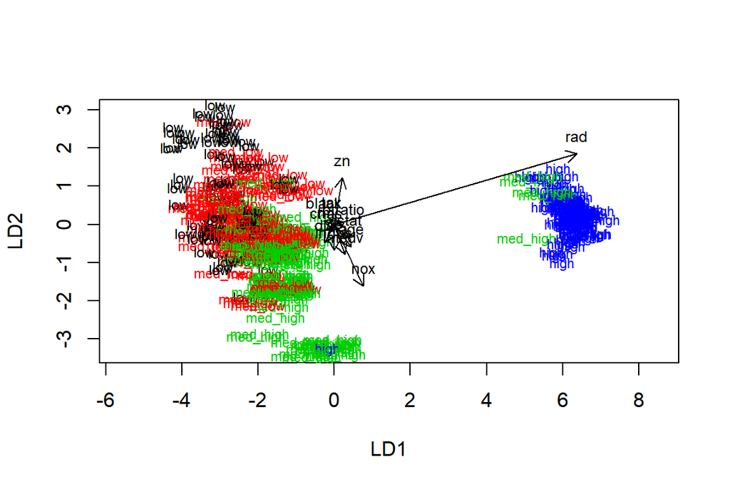

The lda-model predicts very well the belonging to the high crime rate -cathegory.As seen from the propability table below, 100% of the observations in high- crime rate cathegory were correcly classified to the high crime rate group.

```
##           predicted
## correct    low med_low med_high high
##   low       19      11        1    0
##   med_low    4      11        7    0
##   med_high   0      10       16    1
##   high       0       0        0   22
```

```
##           predicted
## correct        low med_low med_high    high
##   low      0.61290 0.35484  0.03226 0.00000
##   med_low  0.18182 0.50000  0.31818 0.00000
##   med_high 0.00000 0.37037  0.59259 0.03704
##   high     0.00000 0.00000  0.00000 1.00000
```

## Distances in the Boston data and clustering

```r
data("Boston")
#str(Boston)
# center and standardize variables
boston_scaled <- scale(Boston)

# summaries of the scaled variables
#summary(boston_scaled)
```

Next, two distance measures were calculated for the Boston data: Euclidean distance matrix and Manhattan distance matrix. The summaries of the distances can be found below.

**Euclidean distance matrix:**

```r
#summary of the distances
summary(dist_eu)
```

```
##    Min. 1st Qu.  Median    Mean 3rd Qu.    Max.
##  0.1343  3.4625  4.8241  4.9111  6.1863 14.3970
```

**Manhattan distance matrix:**

```r
#summary of the distances
summary(dist_man)
```

```
##    Min. 1st Qu.  Median    Mean 3rd Qu.    Max.
##  0.2662  8.4832 12.6090 13.5488 17.7568 48.8618
```

**K-means clustering**

For the k-means cluster, an optimal number of clusters can be decided from the figure below showing number of clusters (1-10) on the x-axis and within class sum of squares (**WCSS**) on the y-axis. As seen from the figure, 2 clusters seem to be the most optimal for clustring.

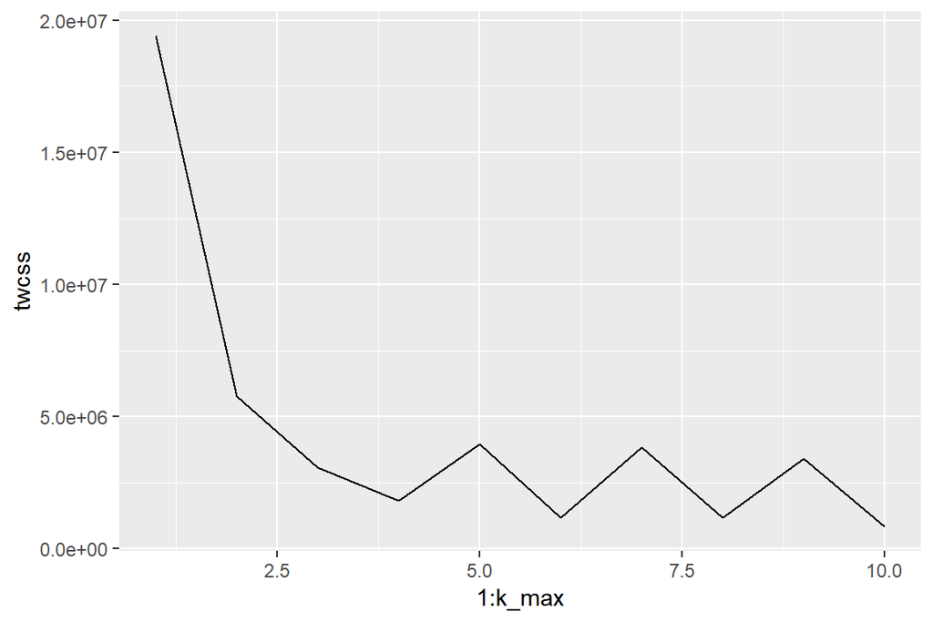

```r
# k-means clustering
# MASS, ggplot2 and Boston dataset are available
# K-means might produce different results every time, because it randomly # assigns the initial cluster centers. The function set.seed() can be used # to deal with that.
set.seed(123)

# determine the number of clusters
k_max <- 10

# calculate the total within sum of squares
twcss <- sapply(1:k_max, function(k){kmeans(Boston, k)$tot.withinss})

# visualize the WCSS results
qplot(x = 1:k_max, y = twcss, geom = 'line')
```

```r
# k-means clustering
km <-kmeans(boston_scaled, centers = 2)

# plot the Boston dataset with clusters
dim(boston_scaled)
```

```
## [1] 506  14
```

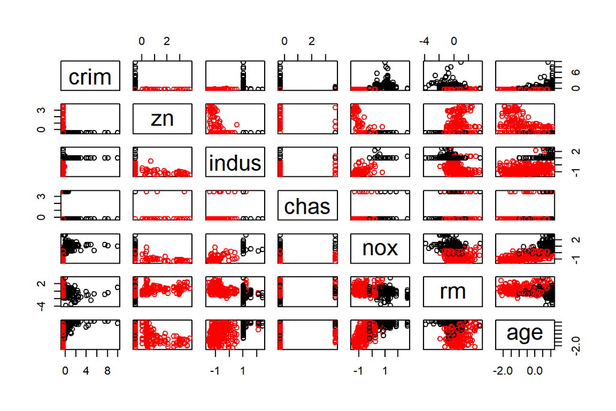

```r
par(mfrow = c(2,1))
pairs(boston_scaled[,1:7], col = km$cluster)
```

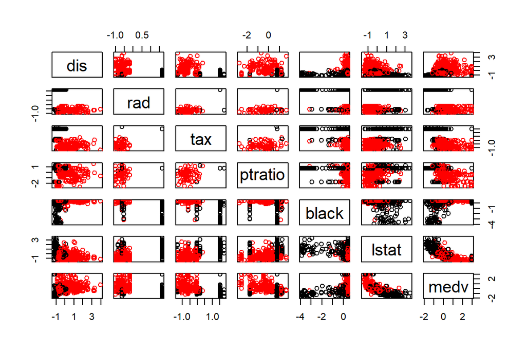

```r
pairs(boston_scaled[,8:14], col = km$cluster)
```

# WEEK 5: Dimensionality reduction techniques:

## Presenting human data

The human data analyzed here is from 155 all around the world. The variables in the dataset are

Edu2.FM = Proportion of females with at least secondary education divided by proportion of males with at least secondary education  
Labo.FM = Proportion of females in the labour force divided by proportion of males in the labour force  
Edu.Exp = Expected years of schooling  
Life.Exp = Life expectancy at birth  
GNI = Gross National Income per capita  
Mat.Mor = Maternal mortality ratio  
Ado.Birth = Adolescent birth rate  
Parli.F = Percetange of female representatives in parliament

and they are summarised below. For example, life expectancy ranges from 49 year to 83.5 years (median 74 years). Huge range can be seen also for example for Gross National income (GNI) which ranges from 581 to 123,124 per capita. Huge range can be seen for education years also (5.4-20.2 years). Not many variables are normally scaled, but they are right or left-tailed. A strong positive correlation can bee seen between GNI and life expectancy (r=0.627)

```
##     Edu2.FM          Labo.FM          Edu.Exp         Life.Exp
##  Min.   :0.1717   Min.   :0.1857   Min.   : 5.40   Min.   :49.00
##  1st Qu.:0.7264   1st Qu.:0.5984   1st Qu.:11.25   1st Qu.:66.30
##  Median :0.9375   Median :0.7535   Median :13.50   Median :74.20
##  Mean   :0.8529   Mean   :0.7074   Mean   :13.18   Mean   :71.65
##  3rd Qu.:0.9968   3rd Qu.:0.8535   3rd Qu.:15.20   3rd Qu.:77.25
##  Max.   :1.4967   Max.   :1.0380   Max.   :20.20   Max.   :83.50
##       GNI            Mat.Mor         Ado.Birth         Parli.F
##  Min.   :   581   Min.   :   1.0   Min.   :  0.60   Min.   : 0.00
##  1st Qu.:  4198   1st Qu.:  11.5   1st Qu.: 12.65   1st Qu.:12.40
##  Median : 12040   Median :  49.0   Median : 33.60   Median :19.30
##  Mean   : 17628   Mean   : 149.1   Mean   : 47.16   Mean   :20.91
##  3rd Qu.: 24512   3rd Qu.: 190.0   3rd Qu.: 71.95   3rd Qu.:27.95
##  Max.   :123124   Max.   :1100.0   Max.   :204.80   Max.   :57.50
```

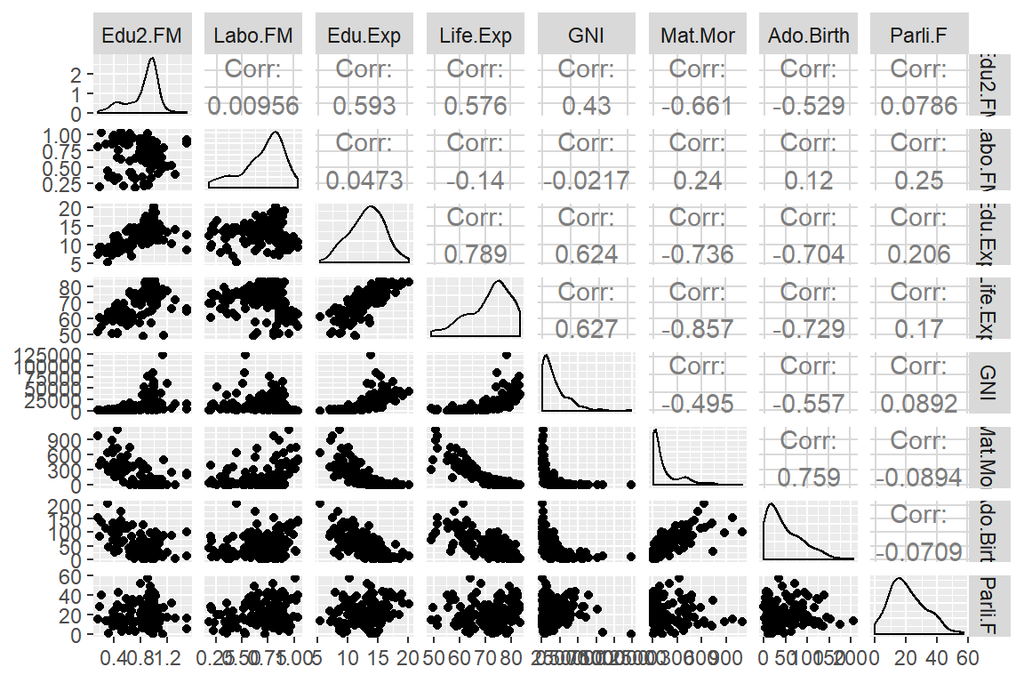

## Pricipal component analysis

First, a pricipal component analysis was performed with unstandardized human data. There PC1 expalined 99.99% of the variation of the data and only 0.01% remained for the PC2. As shown from the biblot, GNI was the variable mainly determining the PC1. And without standardization all the effects from the other variables can not be interpreted.

```
##   PC1   PC2   PC3   PC4   PC5   PC6   PC7   PC8
## 99.99  0.01  0.00  0.00  0.00  0.00  0.00  0.00
```

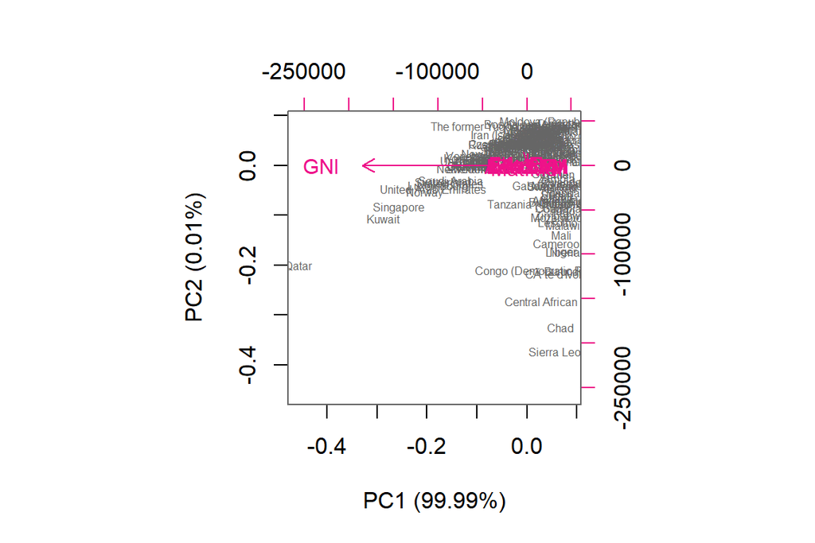

With standardized human data, the pricipal component analysis gives a more informative results not fully dominated by GNI. Now, PC1 explaines 53.6% of the variability, PC1 16.2% and the rest remains for the other PCs. Now we can see, that gross national income per capita (GNI), education years (Edu.exp) and life expentacy (Life.exp) are all very closely correlated.

```
## Importance of components:
##                           PC1    PC2     PC3     PC4     PC5     PC6
## Standard deviation     2.0708 1.1397 0.87505 0.77886 0.66196 0.53631
## Proportion of Variance 0.5361 0.1624 0.09571 0.07583 0.05477 0.03595
## Cumulative Proportion  0.5361 0.6984 0.79413 0.86996 0.92473 0.96069
##                            PC7     PC8
## Standard deviation     0.45900 0.32224
## Proportion of Variance 0.02634 0.01298
## Cumulative Proportion  0.98702 1.00000
```

```
##  PC1  PC2  PC3  PC4  PC5  PC6  PC7  PC8
## 53.6 16.2  9.6  7.6  5.5  3.6  2.6  1.3
```

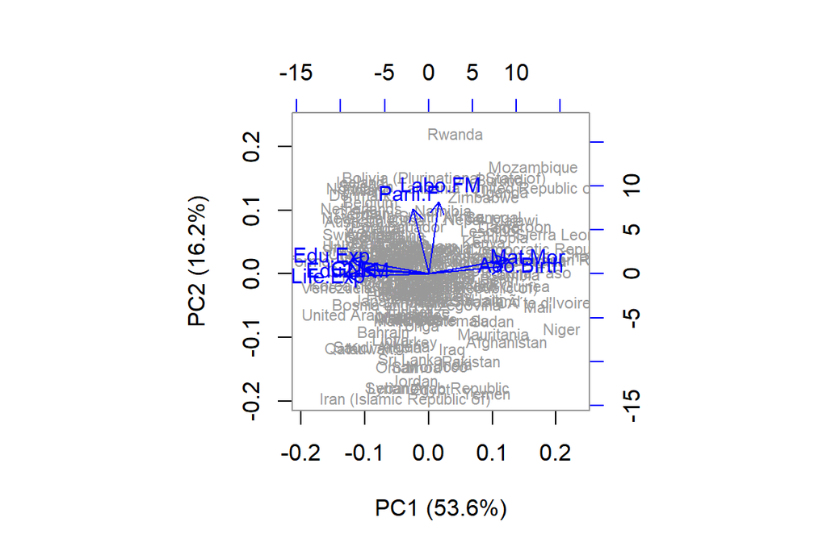

## Tea data presented

It’s all about tea in this dataset of 300 observations of 36 variables related to tea consumption: when, how, with who and where you enjoy your tea. This data is included in the package FactoMineR.

```
## 'data.frame':    300 obs. of  36 variables:
##  $ breakfast       : Factor w/ 2 levels "breakfast","Not.breakfast": 1 1 2 2 1 2 1 2 1 1 ...
##  $ tea.time        : Factor w/ 2 levels "Not.tea time",..: 1 1 2 1 1 1 2 2 2 1 ...
##  $ evening         : Factor w/ 2 levels "evening","Not.evening": 2 2 1 2 1 2 2 1 2 1 ...
##  $ lunch           : Factor w/ 2 levels "lunch","Not.lunch": 2 2 2 2 2 2 2 2 2 2 ...
##  $ dinner          : Factor w/ 2 levels "dinner","Not.dinner": 2 2 1 1 2 1 2 2 2 2 ...
##  $ always          : Factor w/ 2 levels "always","Not.always": 2 2 2 2 1 2 2 2 2 2 ...
##  $ home            : Factor w/ 2 levels "home","Not.home": 1 1 1 1 1 1 1 1 1 1 ...
##  $ work            : Factor w/ 2 levels "Not.work","work": 1 1 2 1 1 1 1 1 1 1 ...
##  $ tearoom         : Factor w/ 2 levels "Not.tearoom",..: 1 1 1 1 1 1 1 1 1 2 ...
##  $ friends         : Factor w/ 2 levels "friends","Not.friends": 2 2 1 2 2 2 1 2 2 2 ...
##  $ resto           : Factor w/ 2 levels "Not.resto","resto": 1 1 2 1 1 1 1 1 1 1 ...
##  $ pub             : Factor w/ 2 levels "Not.pub","pub": 1 1 1 1 1 1 1 1 1 1 ...
##  $ Tea             : Factor w/ 3 levels "black","Earl Grey",..: 1 1 2 2 2 2 2 1 2 1 ...
##  $ How             : Factor w/ 4 levels "alone","lemon",..: 1 3 1 1 1 1 1 3 3 1 ...
```

[output cut: 22 more lines]

[output not shown]

```
## [1] 300  36
```

Trying to visualize all these 36 variables is not very informative. Therefore I chose the following six variables for further analysis: “Tea”, “How”, “how”, “sugar”, “where”, “lunch”. These variables are summarised below:

```
##         Tea         How                      how           sugar
##  black    : 74   alone:195   tea bag           :170   No.sugar:155
##  Earl Grey:193   lemon: 33   tea bag+unpackaged: 94   sugar   :145
##  green    : 33   milk : 63   unpackaged        : 36
##                  other:  9
##                   where           lunch
##  chain store         :192   lunch    : 44
##  chain store+tea shop: 78   Not.lunch:256
##  tea shop            : 30
##
```

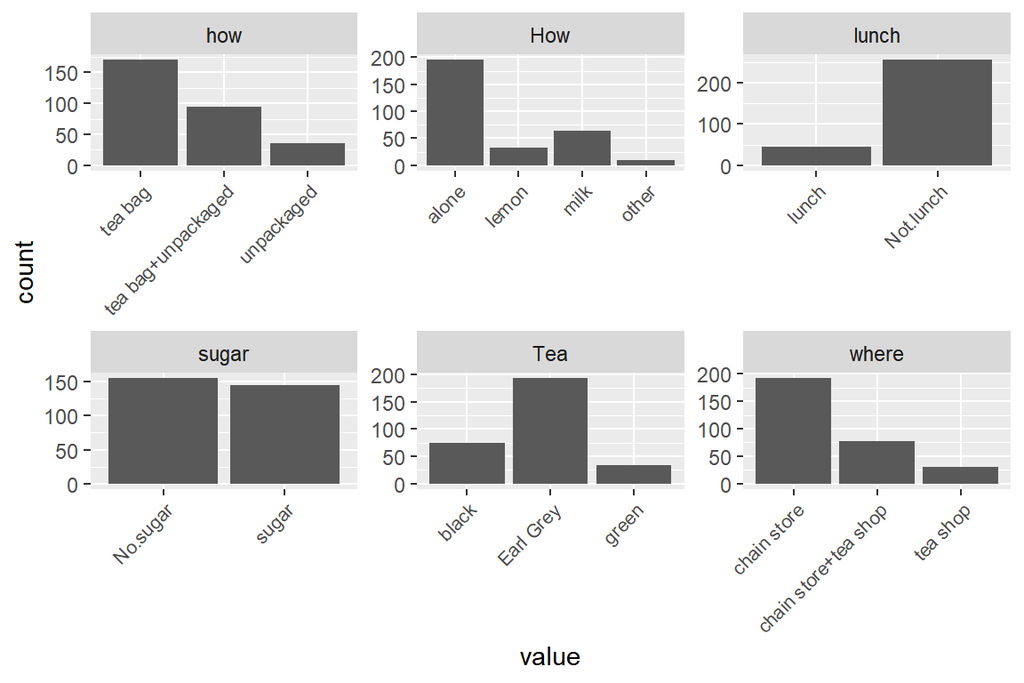

## MCA with Tea data

A multiple correspondance Analysis was performed with the six variables presented above. From the **MCA summary table**, we can see that all variance in the data can be presented in eleven dimensions and 29.5% of the variance are presented with the 1st and second dimensions (figure below) Of the variables, “how” (teaback/unpacked or both) and “where” (tea from chain store/tea shop) correlate most strongly with the two first dimensions in the MCA.

From the **MCA factor map** one can interpret that usually unpacked see is bought from the tea shop and teabacks from the chain store. Also, one can say that green tea is more often drank without milk and lemon or anything (group other). We can also see that most people by their tea from chain stores and they are the users of black and Earl grey tea.

```r
# multiple correspondence analysis
# if graph = TRUE, a graph is drawn to pdf-file
mca <- MCA(tea_time, graph = FALSE)

# summary of the model
# the summary is explained in the video...
summary(mca)
```

```
##
## Call:
## MCA(X = tea_time, graph = FALSE)
##
##
## Eigenvalues
##                        Dim.1   Dim.2   Dim.3   Dim.4   Dim.5   Dim.6
## Variance               0.279   0.261   0.219   0.189   0.177   0.156
## % of var.             15.238  14.232  11.964  10.333   9.667   8.519
## Cumulative % of var.  15.238  29.471  41.435  51.768  61.434  69.953
##                        Dim.7   Dim.8   Dim.9  Dim.10  Dim.11
## Variance               0.144   0.141   0.117   0.087   0.062
## % of var.              7.841   7.705   6.392   4.724   3.385
## Cumulative % of var.  77.794  85.500  91.891  96.615 100.000
##
## Individuals (the 10 first)
##                       Dim.1    ctr   cos2    Dim.2    ctr   cos2    Dim.3
## 1                  | -0.298  0.106  0.086 | -0.328  0.137  0.105 | -0.327
## 2                  | -0.237  0.067  0.036 | -0.136  0.024  0.012 | -0.695
## 3                  | -0.369  0.162  0.231 | -0.300  0.115  0.153 | -0.202
## 4                  | -0.530  0.335  0.460 | -0.318  0.129  0.166 |  0.211
## 5                  | -0.369  0.162  0.231 | -0.300  0.115  0.153 | -0.202
## 6                  | -0.369  0.162  0.231 | -0.300  0.115  0.153 | -0.202
## 7                  | -0.369  0.162  0.231 | -0.300  0.115  0.153 | -0.202
## 8                  | -0.237  0.067  0.036 | -0.136  0.024  0.012 | -0.695
## 9                  |  0.143  0.024  0.012 |  0.871  0.969  0.435 | -0.067
## 10                 |  0.476  0.271  0.140 |  0.687  0.604  0.291 | -0.650
##                       ctr   cos2
## 1                   0.163  0.104 |
## 2                   0.735  0.314 |
## 3                   0.062  0.069 |
## 4                   0.068  0.073 |
## 5                   0.062  0.069 |
## 6                   0.062  0.069 |
## 7                   0.062  0.069 |
## 8                   0.735  0.314 |
## 9                   0.007  0.003 |
## 10                  0.643  0.261 |
##
## Categories (the 10 first)
```

[output cut: 16 more lines]

```
## lemon                0.035   3.226 |   1.329  14.771   0.218   8.081 |
## milk                 0.020   2.422 |   0.013   0.003   0.000   0.116 |
## other                0.102   5.534 |  -2.524  14.526   0.197  -7.676 |
## tea bag              0.161  -6.941 |  -0.065   0.183   0.006  -1.287 |
## tea bag+unpackaged   0.478  11.956 |   0.019   0.009   0.000   0.226 |
## unpackaged           0.141  -6.482 |   0.257   0.602   0.009   1.640 |
##
## Categorical variables (eta2)
##                      Dim.1 Dim.2 Dim.3
## Tea                | 0.126 0.108 0.410 |
## How                | 0.076 0.190 0.394 |
## how                | 0.708 0.522 0.010 |
## sugar              | 0.065 0.001 0.336 |
## where              | 0.702 0.681 0.055 |
## lunch              | 0.000 0.064 0.111 |
```

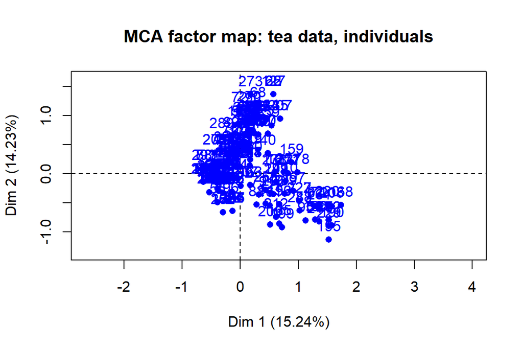

```r
# visualize MCA
# you can either plot the variables or the individuals or both
par = nrow(c(1,2))
plot(mca, invisible=c("var"),
    title ="MCA factor map: tea data, individuals")
```

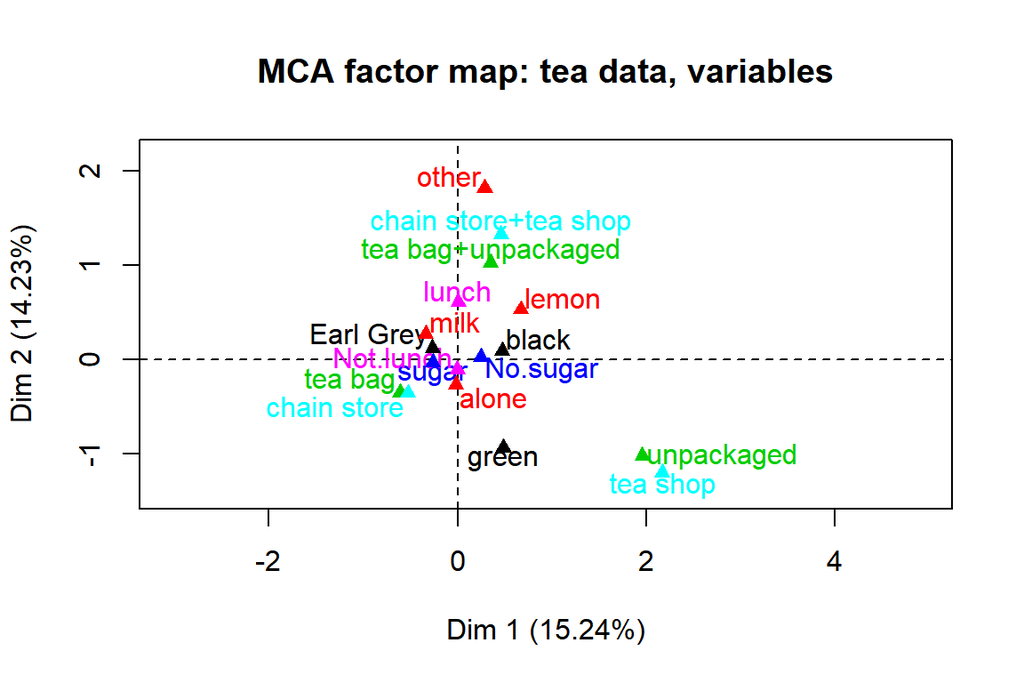

```r
plot(mca, invisible=c("ind"),
     habillage = "quali", title ="MCA factor map: tea data, variables")
```

# Week 6: Analysis of longitudinal data

## BPRS data

**Data presented**

The BPRS data is a analysed similarly as in the chapter 9 in the book **MABS (Vehkalahti and Everitt, 2019)**

The BPRS dataset consist of weekly BPRS (brief psychiatric rating scale) measurements of 40 men divided into two treatment groups. There are nine measurements per person of which the first is the baseline measurement and eight are measurements during the follow-up. We can see that weekly BPRS score mainly ranges between 18-95.

```
## [1] "treatment" "subject"   "weeks"     "bprs"      "week"
```

```
## 'data.frame':    360 obs. of  5 variables:
##  $ treatment: int  1 1 1 1 1 1 1 1 1 1 ...
##  $ subject  : int  1 2 3 4 5 6 7 8 9 10 ...
##  $ weeks    : Factor w/ 9 levels "week0","week1",..: 1 1 1 1 1 1 1 1 1 1 ...
##  $ bprs     : int  42 58 54 55 72 48 71 30 41 57 ...
##  $ week     : int  0 0 0 0 0 0 0 0 0 0 ...
```

```
##    treatment      subject          weeks          bprs            week
##  Min.   :1.0   Min.   : 1.00   week0  : 40   Min.   :18.00   Min.   :0
##  1st Qu.:1.0   1st Qu.: 5.75   week1  : 40   1st Qu.:27.00   1st Qu.:2
##  Median :1.5   Median :10.50   week2  : 40   Median :35.00   Median :4
##  Mean   :1.5   Mean   :10.50   week3  : 40   Mean   :37.66   Mean   :4
##  3rd Qu.:2.0   3rd Qu.:15.25   week4  : 40   3rd Qu.:43.00   3rd Qu.:6
##  Max.   :2.0   Max.   :20.00   week5  : 40   Max.   :95.00   Max.   :8
##                                (Other):120
```

```
##    Min. 1st Qu.  Median    Mean 3rd Qu.    Max.
##       0       2       4       4       6       8
```

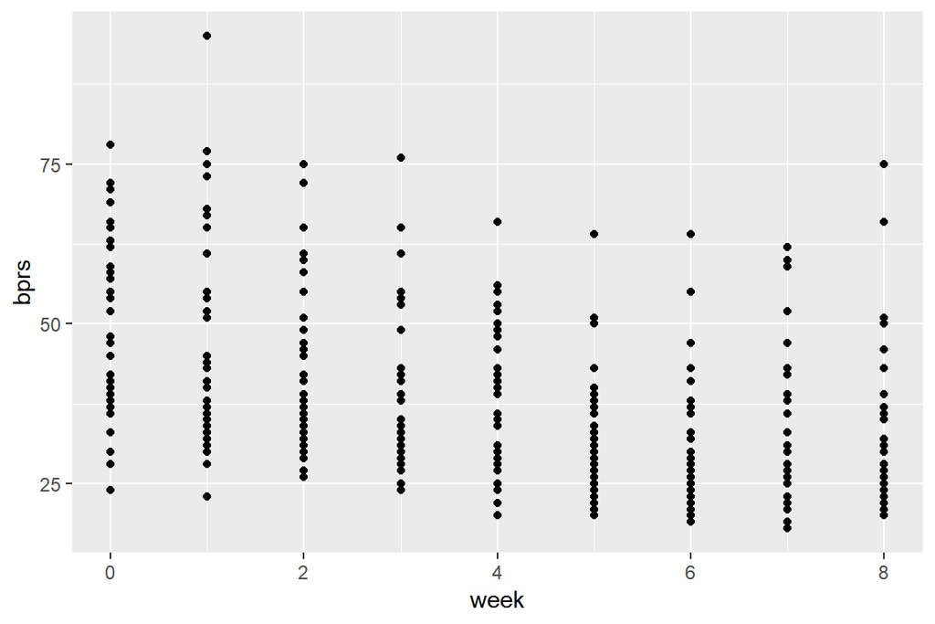

```r
library(ggplot2)
ggplot(B_L, aes(x = week, y = bprs, group = subject)) +
geom_point()
```

**Linear regression with the BPRS data**

First we again ignore the longitudinal format of the data (and several measurements from individuals) and we fit a linear regression model for the BRPS data which tries to resolve how the treatment affect the BPRS.

```r
B_lm <- lm(bprs ~ week + treatment, data = B_L)

# print out a summary of the model
summary(B_lm)
```

```
##
## Call:
## lm(formula = bprs ~ week + treatment, data = B_L)
##
## Residuals:
##     Min      1Q  Median      3Q     Max
## -22.454  -8.965  -3.196   7.002  50.244
##
## Coefficients:
##             Estimate Std. Error t value Pr(>|t|)
## (Intercept)  46.4539     1.3670  33.982   <2e-16 ***
## week         -2.2704     0.2524  -8.995   <2e-16 ***
## treatment2    0.5722     1.3034   0.439    0.661
## ---
## Signif. codes:  0 '***' 0.001 '**' 0.01 '*' 0.05 '.' 0.1 ' ' 1
##
## Residual standard error: 12.37 on 357 degrees of freedom
## Multiple R-squared:  0.1851, Adjusted R-squared:  0.1806
## F-statistic: 40.55 on 2 and 357 DF,  p-value: < 2.2e-16
```

From the linear regression **model summary** we can see that weeks affects the bprs but the treatment does not. You shoud not this model however. Next, we will do a proper analysis.

**liner mixed model analysis**

A proper analysis model for this longitudinal data is linear mixed model with random slope and random intercept. We however, first perform a random intercept model only

```
## Linear mixed model fit by maximum likelihood  ['lmerMod']
## Formula: bprs ~ week + treatment + (1 | subject)
##    Data: B_L
##
##      AIC      BIC   logLik deviance df.resid
##   2748.7   2768.1  -1369.4   2738.7      355
##
## Scaled residuals:
##     Min      1Q  Median      3Q     Max
## -3.0481 -0.6749 -0.1361  0.4813  3.4855
##
## Random effects:
##  Groups   Name        Variance Std.Dev.
##  subject  (Intercept)  47.41    6.885
##  Residual             104.21   10.208
## Number of obs: 360, groups:  subject, 20
##
## Fixed effects:
##             Estimate Std. Error t value
## (Intercept)  46.4539     1.9090  24.334
## week         -2.2704     0.2084 -10.896
## treatment2    0.5722     1.0761   0.532
##
## Correlation of Fixed Effects:
##            (Intr) week
## week       -0.437
## treatment2 -0.282  0.000
```

```
## Linear mixed model fit by maximum likelihood  ['lmerMod']
## Formula: bprs ~ week + treatment + (week | subject)
##    Data: B_L
##
##      AIC      BIC   logLik deviance df.resid
##   2745.4   2772.6  -1365.7   2731.4      353
##
## Scaled residuals:
##     Min      1Q  Median      3Q     Max
## -2.8919 -0.6194 -0.0691  0.5531  3.7976
##
## Random effects:
##  Groups   Name        Variance Std.Dev. Corr
##  subject  (Intercept) 64.8202  8.0511
##           week         0.9608  0.9802   -0.51
##  Residual             97.4307  9.8707
## Number of obs: 360, groups:  subject, 20
##
## Fixed effects:
##             Estimate Std. Error t value
## (Intercept)  46.4539     2.1052  22.066
## week         -2.2704     0.2977  -7.626
## treatment2    0.5722     1.0405   0.550
##
## Correlation of Fixed Effects:
##            (Intr) week
## week       -0.582
## treatment2 -0.247  0.000
```

When we compare the two LMM model created, we can see that the random intercept random slope model is better.

```r
anova(B_rand_i,B_rand_i_s)
```

```
## Data: B_L
## Models:
## B_rand_i: bprs ~ week + treatment + (1 | subject)
## B_rand_i_s: bprs ~ week + treatment + (week | subject)
##            Df    AIC    BIC  logLik deviance  Chisq Chi Df Pr(>Chisq)
## B_rand_i    5 2748.7 2768.1 -1369.4   2738.7
## B_rand_i_s  7 2745.4 2772.6 -1365.7   2731.4 7.2721      2    0.02636 *
## ---
## Signif. codes:  0 '***' 0.001 '**' 0.01 '*' 0.05 '.' 0.1 ' ' 1
```

```
## Linear mixed model fit by maximum likelihood  ['lmerMod']
## Formula: bprs ~ week + treatment + (week | subject) + week * treatment
##    Data: B_L
##
##      AIC      BIC   logLik deviance df.resid
##   2744.3   2775.4  -1364.1   2728.3      352
##
## Scaled residuals:
##     Min      1Q  Median      3Q     Max
## -3.0512 -0.6271 -0.0767  0.5288  3.9260
##
## Random effects:
##  Groups   Name        Variance Std.Dev. Corr
##  subject  (Intercept) 65.0016  8.0624
##           week         0.9688  0.9843   -0.51
##  Residual             96.4699  9.8219
## Number of obs: 360, groups:  subject, 20
##
## Fixed effects:
##                 Estimate Std. Error t value
## (Intercept)      47.8856     2.2522  21.262
## week             -2.6283     0.3589  -7.323
## treatment2       -2.2911     1.9090  -1.200
## week:treatment2   0.7158     0.4010   1.785
##
## Correlation of Fixed Effects:
##             (Intr) week   trtmn2
## week        -0.650
## treatment2  -0.424  0.469
## wek:trtmnt2  0.356 -0.559 -0.840
```

```
## Data: B_L
## Models:
## B_rand_i_s: bprs ~ week + treatment + (week | subject)
## B_rand_interact: bprs ~ week + treatment + (week | subject) + week * treatment
##                 Df    AIC    BIC  logLik deviance  Chisq Chi Df Pr(>Chisq)
## B_rand_i_s       7 2745.4 2772.6 -1365.7   2731.4
## B_rand_interact  8 2744.3 2775.4 -1364.1   2728.3 3.1712      1    0.07495
##
## B_rand_i_s
## B_rand_interact .
## ---
## Signif. codes:  0 '***' 0.001 '**' 0.01 '*' 0.05 '.' 0.1 ' ' 1
```

**Plot observed and fitted values**

Next we just want to plot the observed and fitted bprs values. For the fitted model values, we’ll use the random intercept random slope model without interction-term. ** I can not get this work with BPRS data** propably because **subject** is not a unique number that it should be when analysing human data. If I see two same subject numbers I assume that they are the same person! I don’t understand how they are different people with differing treatment in this dataset..

```r
#ggplot(B_L, aes(x = week, y = bprs, group =subject)) +
#  geom_line(aes(alpha = treatment))
#  scale_x_continuous(name = "Time (weeks)", breaks = seq(0,8,2)) +
#  scale_y_continuous(name = "Observed bprs (points) ") +
#  theme(legend.position = "top")
# this not working
```

## RATS data

Unfortunately I have ony time for a quick LMM with the RATS-data (3 groups, weight measurements). So here you go, results from LMM checking if group affect the weight change. And yes, this can be seen, and group affect significanly the rate of weight change (model with interaction better).

```r
#THIS CODE WORKING IN RSTUDIO but when knitting.. "data" not found, and some variables missing etc blaa  #blaa. I put # because othewise it destroys knitting this whole document...
#RATS <- read.table("~/Tyojuttuja/opinnot/GitHub/IODS-project/data/rats_long.txt", header=T, sep = "\t")
#str(RATS)

#factor variables
#RATS$ID <- factor(RATS$ID)
#RATS$Group <- factor(RATS$Group)

# create a random intercept and random slope model
#RATS_ref1 <- lmer(Weight ~ Time + Group + (Time | ID), data = RATS, REML = FALSE)
#
#summary(RATS_ref1)

# create a random intercept and random slope model with the interaction
#RATS_ref2 <- lmer(Weight ~ Group + Time + (Time|ID) +Time*Group, REML= FALSE, data= RATS)

#summary(RATS_ref2)

# perform an ANOVA test on the two models
#anova(RATS_ref2, RATS_ref1)

#Data: RATS
#Models:
#RATS_ref1: Weight ~ Time + Group + (Time | ID)
#RATS_ref2: Weight ~ Group + Time + (Time | ID) + Time * Group
#          Df    AIC    BIC  logLik deviance  Chisq Chi Df Pr(>Chisq)
#RATS_ref1  8 1194.2 1219.6 -589.11   1178.2
#RATS_ref2 10 1185.9 1217.6 -582.93   1165.9 12.361      2    0.00207 **
#---
#Signif. codes:  0 â***â 0.001 â**â 0.01 â*â 0.05 â.â 0.1 â â 1
```